# Past Performance *Is* Indicative of Future Results

Momentum Strategies in the U.S. Equity Markets

Gregory Langner

Union College Department of Economics Senior Thesis

March 2018

Abstract

I successfully replicate the findings of Asness, Moskowitz, and Pedersen (2013) that momentum strategies in zero cost, long-short neutral portfolios are profitable. I expand on their work in three ways: First, I find that profits are much higher when momentum portfolios are constructed using only top and bottom decile performers rather than top and bottom half performers. Second, I find that 6-month return signals are much less profitable than 12-month return signals. Finally, I find that the returns of momentum portfolios outperform a zero cost portfolio that is long the S&P 500 and short a riskless asset that yields 0.5% per month.

### 1. Introduction

This thesis examines momentum in the U.S. equity markets through the evaluation of historical returns and construction of zero cost, long-short neutral portfolios. The efficient market hypothesis operates under the assumption that asset prices fully reflect all information available. This implies that there are no opportunities to consistently outperform the market on a risk adjusted basis. Thus, past returns should have no predictive power for future performance. Despite this theory, academic literature provides evidence of momentum across various asset classes. By definition, momentum is the empirically observed tendency for rising asset prices to rise further, and falling prices to keep falling ([Jegadeesh and Titman, 2001](https://www.jstor.org/stable/222579?seq=1#page_scan_tab_contents)). My goal is twofold: first, I seek to replicate existing findings using my own data and programs; second, I seek to examine alternative strategies to momentum investing and evaluate the reasons for variations in the performance of momentum portfolios.

To fulfill my first goal, I construct a zero cost, long-short neutral portfolio modeled after [Asness, Moskowitz, and Pedersen (2013)](http://pages.stern.nyu.edu/~lpederse/papers/ValMomEverywhere.pdf) (AMP hereafter) using the data analytics program, RStudio. I examine the results of my portfolio relative to the results found in AMP and evaluate the differences in the methods of portfolio construction. Following the completion of a portfolio modeled after that which is found in AMP, I construct two additional portfolios: one which only includes stocks that display strong momentum signals, and one which evaluates momentum over a different timeline. I interpret the findings of alternative momentum strategies relative to the results of both AMP, and the portfolio that I construct using the original model.

### 2. Literature Review

[AMP](http://pages.stern.nyu.edu/~lpederse/papers/ValMomEverywhere.pdf), examine value and momentum simultaneously across eight different asset classes: individual stocks in the U.S., U.K., continental Europe, and Japan; country equity index futures, government bonds; currencies, and commodity futures. Cliff Asness is the founding partner of [AQR Capital Management](https://www.aqr.com/), an investment management firm in Greenwich, Connecticut which manages almost $200 billion worth of assets. AMP examine value and momentum both individually and together, among assets with high liquidity to best represent an active trading strategy, but also note that the results from the study are conservative due to the tendency of assets with low liquidity to behave strongly in accordance to momentum theory. AMP also state that “The strong correlation structure among value and momentum strategies across such diverse asset classes is difficult to reconcile under existing behavioral theories”, and proceed to point out that “the high return premium and Sharpe ratio of a global across-asset-class diversified value and momentum portfolio presents an even more daunting hurdle for rational risk based models…”. The portfolio construction strategy implemented in this study serves as the foundation from which I build my own model to examine momentum and portfolio strategies among U.S. equities.

[Cochrane (1999)](http://faculty.chicagobooth.edu/john.cochrane/research/papers/ep3q99_4.pdf) discusses the evolving world of portfolio management and the evolving nature of investing and investors’ ability to process new information and alternative methods for investing. The theme of the paper focuses on risk, and how much risk an investor is able to be exposed to. Cochrane (1999) notes that an individual who is already exposed to a certain industry or sector of the market by means of their business or other investments should avoid additional exposure to the same industry or sector. Cochrane (1999) also states that risk is factored into the market, and those who are overexposed to risk can hedge their investments, however those who are able to accumulate risk can earn a premium by gaining exposure that others are actively avoiding. Cochrane (1999) also includes a defined metric of uncertainty in a portfolio that is derived from historical performance.

[Jegadeesh and Titman, 2001](https://www.jstor.org/stable/222579?seq=1#page_scan_tab_contents) revisit [Jegadeesh and Titman (1993)](https://www.jstor.org/stable/2328882?seq=1#page_scan_tab_contents) which examined “a variety of momentum strategies and document that strategies which buy stocks with high returns over the previous 3 to 12 months and sell stocks with poor returns over the same time period earn profits of about one percent per month for the following year”. Jegadeesh and Titman (1993) spark a considerable debate regarding the accuracy of the empirical results. One of the suggested behavioral models addressed in Jegadeesh and Titman (2001) suggests a bandwagon type theory in which investors are naturally attracted to stocks with a strong history of returns. Another behavioral suggestion, which Jegadeesh and Titman deem the most notable, states that cross sectional variation in expected returns explains the success of momentum investing, opposed to “any predictable time-series variations in stock returns.” With additional data to supplement their previous work, Jegadeesh and Titman (2001) note that “momentum strategies continue to be profitable and that past winners outperform past losers by about the same magnitude as in the earlier period”. Jegadeesh and Titman (2001) find that the new research with additional data is remarkably similar to the previous findings, confirming that the results previously published were not a product of data snooping. Jegadeesh and Titman (1993) found that momentum strategies generate positive returns in all months except for January. This finding did not yield much significance, and was initially written off as a fluke. However, the new work with additional data outside of the original sample consistently yields the same findings in the month of January, indicating that this is not necessarily a fluke. Jegadeesh and Titman (2001) address behavioral models that seek to explain momentum, yet the use of fundamental modeling confirms the evidence of momentum previously proposed in Jegadeesh and Titman (1993).

[Bollen and Busse (2004)](http://www.empirical.net/wp-content/uploads/2014/12/Bollen-Busse-Short-term-Persistence-in-Mutual-Fund-Performance-RFS04.pdf) examine mutual funds as opposed to single stocks, however the nature of their short term evaluation of securities is a significant contribution to the literature concerning evidence of momentum across multiple timelines. Bollen and Busse (2004) focus on periods of three months using daily returns to mutual funds and employ Carhart’s four-factor model, which is a modification of the widely used Fama and French Three Factor Model. After the modification of various models to be applied to short term performance, Bollen and Busse (2004) find that persistence, the observed tendency of a security to closely track an equity index, is actually a short term phenomenon. The tendencies of momentum and persistence, when researched in the long run, is seen to erase some of the gains that can be capitalized on with an actively managed stock portfolio.

[Cooper, Gutierrez, and Hameed (2004)](http://onlinelibrary.wiley.com/doi/10.1111/j.1540-6261.2004.00665.x/abstract) test theories of short-run momentum based on the overall state of the market. The paper confirms the concept found in Jegadeesh and Titman (2001) that short run momentum gains are reversed in the long run. In addition to examining the state of the market relative to the performance of momentum investing, Cooper, Gutierrez, and Hameed (2004) address previous research which suggests that various macroeconomic variables can explain momentum profits. Upon further investigation, Cooper, Gutierrez, and Hameed (2004) conclude that there is no model that explains any effect that macroeconomic factors have on the performance of stocks which have been deemed to be “prior winners” or “prior losers”. Cooper, Gutierrez, and Hameed (2004) notice that there is a “nonlinear relation between momentum profits and lagged market states. As the lagged market return increases, momentum increases and reaches a peak near the median level of market performance, slowly declining thereafter.” This is a significant contribution to the evaluation and explanation of the momentum premium, as well as the efforts to effectively construct profitable momentum portfolios.

[Korajczyk and Sadka (2004)](http://onlinelibrary.wiley.com/doi/10.1111/j.1540-6261.2004.00656.x/abstract) are cited by AMP in a brief discussion of the transaction costs of momentum investing and the feasibility of implementing such a method of portfolio construction. Unlike AMP, Korajczyk and Sadka (2004) employ a long only portfolio in lieu of a long-short neutral strategy. Korajczyk and Sadka (2004) state that past losers are much less liquid than past winners, therefore there is a higher price impact of trading the securities. Additionally it is noted that trading costs between a long position and an equally weighted short position are not necessarily symmetrical. Korajczyk and Sadka (2004) employ four separate methods of measuring trading costs. Two of the four methods are independent of portfolio size, and the remaining two are referred to as “nonproportional trading cost models” which reflect the increase in trading costs with the size of the position traded. Korajczyk and Sadka (2004) also emphasize that the profitability of equal weighted strategies decline when compared to other strategies such as value weighted and liquidity weighted portfolios. Korajczyk and Sadka (2004) conclude that momentum strategies still remain profitable under transaction cost methodos that are equal to the effective and quoted spreads.

Lesmond, Schill, and Zhou (2003) also examine the costs of momentum trading strategies and conclude that “the magnitude of the abnormal returns associated with these trading strategies creates an illusion of profit opportunity when, in fact, none exists.” Lesmond, Schill, and Zhou (2003) note that momentum is observed to be the strongest among securities with high transaction costs related primarily to liquidity. This issue is addressed when referencing Jegadeesh and Titman (2001) and the decision to implement large market capitalization stocks which tend to exhibit weaker signals of momentum. Granted, smaller market capitalization stocks exhibit momentum consistently, the results of Lesmond, Schill, and Zhou (2003) suggest that the high trading costs significantly reduce overall profitability and leave the possibility of profiting from momentum to positions in large companies.

Frazzini, Israel, and Moskowitz (2012) use almost one trillion dollars of live trading data to examine the real world transaction costs of various investment strategies, including momentum. Unlike Lesmond, Schill, and Zhou (2003) and Korajczyk and Sadka (2004), the results found by Frazzini, Israel, and Moskowitz (2012) indicate that there are in fact implementable strategies that can reduce transaction costs such that there is robust profitability from standard momentum investing. The research focuses on institutional money managers which invested in 19 developed equity markets from the period ranging from 1998 to 2011. When measuring transaction costs, Frazzini, Israel, and Moskowitz (2012) use the “implementation shortfall” methodology, which “measures the difference between a theoretical or benchmark price (e.g., a model price) and an actual traded price, scaled by the amount traded”. Frazzini, Israel, and Moskowitz (2012) also define market impact as “the difference between an arrival price (i.e., the price that exists when a trade begins in the market) and an actual traded price, scaled by the amount traded”. Unlike other literature previously mentioned above, the portfolio construction methods in Frazzini, Israel, and Moskowitz (2012) are conducted with transaction costs in mind, and effectively reduce the costs suggested in previous research, optimizing the abnormal returns of momentum trading strategies.

### 3. Empirical Methodology

My empirical methodology follows that of AMP. To construct the portfolio, I examine monthly performance using end of month stock prices and calculate month over month return. The adjusted close on the last day of each month serves as the figure to measure the month over month performance. To evaluate momentum, AMP evaluate the 12-month return of a security, skipping the most recent month. AMP cite that it is common in momentum literature to skip the most recent month prior to portfolio construction to ensure that all available information has been absorbed into the market. I construct my portfolio with each of the prior 12 months of returns present. Consistent with AMP, I use the 12-month return statistic, to generate a “rank” for each stock during each month. Stocks with the best 12-month returns are ranked highest, and stocks with a worse return receive a lower rank, with the worst stock receiving a rank of 1.

The rank is then used to create a “weight” variable, which is used to derive the actual weight of the stock in the portfolio. The mean of all ranks assigned during that particular time period *t* is then subtracted from the individual rank of stock *i*. Therefore, the stocks that perform particularly well or particularly poorly receive a more significant weight in the portfolio. Stocks that display weaker signals of momentum consequently have less weight in the portfolio. The total number of stocks present during time *t* is expressed as *N*, and *$S_{it}$* denotes the momentum signal from which each stock is ranked.

The weight formula exhibited below includes a scaling factor, *$c_{t}$*, so that the portfolio is consistently one dollar long and one dollar short. In order to create the scaling factor, each stock is weighted using the formula below, without the scaling factor. The original, unscaled weights only serve the purpose of deriving the scaled weights to be included in the portfolio. The sum of all scaled weights greater than 0 assigned at time *t* must equal 1, and the sum of all scaled weights less than 0 at time *t* must equal -1. The scaling factor is calculated to be the sum of all unscaled weights greater than 0 at time *t*. The new scaled weight for an individual stock is the original weight divided by *$c_{t}$*. Consequently, the sum of all new weights less than 0 during any given month is equal to -1, and the sum of all new weights greater than 0 during given month is equal to 1.

$$w_{it}^s = c_{t}(rank(S_{it})-\sum_{}rank(S_{it})/N)$$

These weights are calculated for each stock, each month. The portfolio that is constructed based on these weights is held for one month before being rebalanced based on a new set of momentum signals. The return, *r*, of the portfolio held over the course of the next month is calculated with the equation below. The return of the portfolio is shown to be the sum of each stock’s weight, *$w_{i}$*, multiplied by its respective return, *$r_{i}$*, at time *t*.

$$r_{t}^S = \sum{}_{i}w_{it}^Sr_{it}$$

I encountered potential issues with the way momentum is evaluated and implemented in a factor based portfolio as modeled above. The following issues are only matters relative to measuring momentum, and are not entirely unique to this specific model. The first matter concerns evaluating 12-month return and a matter of market crashes such as those which occurred around 2001 and 2008. Stocks which experience a sharp decline in a short period of time, followed by a slow yet steady recovery can display a negative 12-month return. Granted that this is an accurate measure of momentum, a stock which has experienced a sharp drop followed by 11 months of recovery may still receive a rank that results in a short position in the portfolio. I address this idea in section 6 by evaluating momentum signals based on 6 months of past returns, instead of 12 months.

The second issue that I encountered with this methodology concerns stocks with positive returns potentially receiving short positions and stocks with negative returns potentially receiving long positions in the portfolio. The stock returns evaluated in this thesis are measured relative to the returns of other stocks across the same timeline. In the event that more than half of the stocks at any given time exhibit positive returns, those which demonstrate positive returns that are less than the top half of stocks present at the time will still receive a short position in the portfolio. I address this idea in section 6 by constructing and evaluating a portfolio that only includes the top and bottom decile of stocks’ 12-month returns.

### 4. Data

#### 4.1. Sources

I use data from the United States equity markets. This is the largest equity market in the world and there are numerous reliable sources to collect data from. Additionally, large market capitalization equities are highly liquid and require low transaction costs relative to other asset classes.

The data I use for this thesis is a file titled “Wiki EOD Stock Prices”, available on the online financial and economic data platform, [Quandl](https://www.quandl.com/databases/WIKIP). The file contains over 15 million individual observations across three thousand stocks, with observations dating as far back as 1962. The file includes ticker symbols, dates, open and close prices, daily high and low prices, trading volumes, expected dividends, stock split ratios, and figures for all of the variables just listed which have been adjusted for stock splits and reverse stock splits. To examine the data efficiently and replicate the model used by AMP, I transform the daily information into end of month data. I conduct the data analysis and further manipulation with the programming language R, and have published the file in a repository on the online hosting service, [GitHub](https://github.com/greglangner/momentum/blob/master/momentum.Rmd). AMP and other momentum researchers obtain historical data from the [Center for Research in Security Prices (CRSP)](http://www.crsp.com/), which is likely to be a better quality source for the information described above.

#### 4.2. Sample of stocks

There are important differences between the data used by AMP and myself for the construction of momentum portfolios. One notable issue is the survivorship bias. It is unclear if the momentum portfolio constructed by AMP includes stocks which filed for bankruptcy or were delisted from a public exchange for any reason. Because AMP obtain data from CRSP, a very reliable source for information on securities, it is likely that AMP had access to information on delisted stocks. It is unclear if the portfolio constructed by AMP includes these securities. My universe of stocks does not include companies which were delisted from a stock exchange. All stocks included in my universe are present and actively traded as of October, 2017. Given that the momentum portfolio is neutral with respect to the overall market, it is not clear whether or not this was a differentiating factor in the performance of my portfolio relative to that of AMP.

An additional issue to make note of is simply the number of stocks included in each portfolio. The universe of stocks used by AMP begins in January 1972, with a portfolio that includes 354 of the largest firms at the time. The data which I access includes information dating to 1963, however I exclude this data and begin portfolio construction in 1972, the same time as AMP. The universe that I begin with only has information on 28 stocks during the first portfolio constructed in January 1972. My universe quickly grows, and by 1989 is limited to the 500 stocks with the highest monthly trading value. This is exhibited in Figure 1. This is consistent across each portfolio constructed in 1989 and afterward, while AMP expand the universe of stocks from 354 to 676 of the largest firms by the end of the sample period in July 2011. AQR Capital Management discloses the [performance of the momentum portfolio](https://www.aqr.com/Insights/Datasets/Value-and-Momentum-Everywhere-Factors-Monthly) constructed by AMP, and includes up to date information beyond July 2011, however it is not clear if the universe of stocks has grown since the publication of the last portfolio.

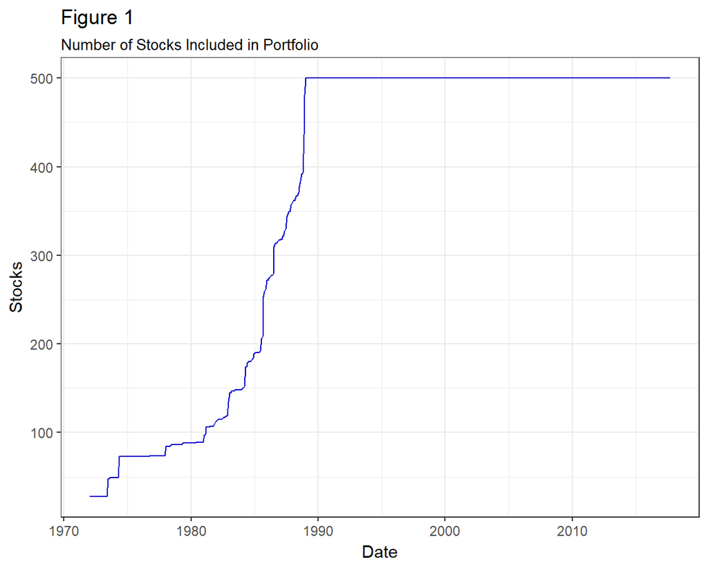

The universe of stocks from which AMP construct a momentum portfolio is based on market capitalization. This statistic was not present in the data which I had access to. As a measure of liquidity, I evaluate the total value of trading volume for each stock, each month. The 500 securities with the highest trading value during the month are then used to construct my portfolio.

Another key difference between my universe and AMP’s universe is the inclusion of financials. AMP mention a variety of the securities excluded from their universe, including financials. My data does not exclude any securities based on sector. Figure 2 compares the returns of my momentum portfolio to that of AMP, and a major difference can be seen during the financial crisis which began in 2008. It is possible that excluding financials from a portfolio at this point would be beneficial, however it is not clear whether or not this was a determining factor in the performance differences between my portfolio and AMP’s portfolio.

#### 4.3. Descriptive Statistics

Table I displays the descriptive statistics of the monthly level stock data that I use to construct a portfolio. Monthly Trading Value is calculated as the sum of daily trading value over the course of the month. The daily trading value is calculated as the total volume of shares multiplied by the adjusted close price for the stock at the end of each day.

**Table I**

| Statistic | N | Mean | St. Dev. | Min | Median | Max |
| --- | --- | --- | --- | --- | --- | --- |
| Monthly Trading Value (Millions USD) | 201,251 | 2,151.740 | 7,536.771 | 0.000 | 616.371 | 1,267,978.000 |
| 1-Month Return | 201,251 | 0.016 | 0.133 | -0.902 | 0.012 | 11.706 |
| 12-Month Return | 201,251 | 0.255 | 0.825 | -0.991 | 0.146 | 93.214 |
| Descriptive statistics of the original Wiki EOD Stock Price data set after being transformed into a monthly format. |  |  |  |  |  |  |

The 1-Month Return and 12-Month Return figures reported in Table I reveal mean returns that are noticeably greater than their respective medians. This upward bias is the result of unlimited upside and limited downside. There is no true limit to growth for an individual stock, as exhibited by one stock which reached a return of 1,170% in a single month. A stock’s downside is normally limited to -100%, but in the case of a data set which does not include stocks whose price went all the way to 0, the worst performance belongs to a security which fell -99.1% over the course of 12 months. This restriction produces the observed upward bias for mean stock returns.

### 5. Results

#### 5.1. Portfolio Construction

Figure 2 displays the cumulative returns of the momentum portfolios constructed from January 1972 through September 2017 using the methodology found in AMP. The returns for the portfolio constructed by AMP have been reported on the website of AQR Capital Management. The information collected from AQR Capital Management only included monthly returns, therefore I independently calculated cumulative gains to observe growth of the portfolio over time. The descriptive statistics for monthly returns to both momentum portfolios are reported in Table II.

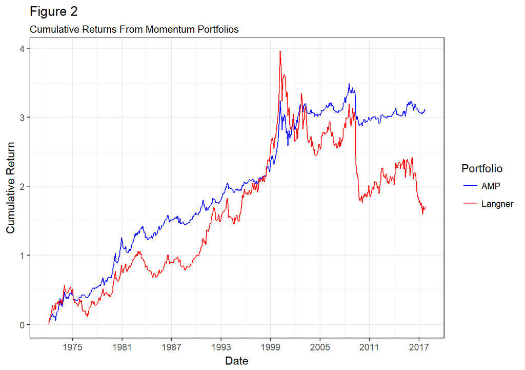

**Table II**

| Statistic | N | Mean | St. Dev. | Min | Median | Max |
| --- | --- | --- | --- | --- | --- | --- |
| AMP | 549 | 0.006 | 0.046 | -0.246 | 0.006 | 0.305 |
| Langner | 549 | 0.003 | 0.081 | -0.521 | 0.008 | 0.440 |
| Descriptive statistics of momentum portfolio returns from January 1972 through September 2017. |  |  |  |  |  |  |

#### 5.2. Sources of Momentum Returns

I find evidence of correlation between monthly stock return and the previous 12-month return of the stock. Of the 549 months when a portfolio was constructed from January 1972 through September 2017, 499 months revealed positive correlation between stock returns and previous 12-month return. Mean correlation between 1-month return and 12-month return over the sample time period is calculated to be 0.274. Figure 3 displays the correlation observed over 549 months. The fitted red line demonstrates consistent, positive correlation over time, although it appears to mildly decrease over the sample time period. Intuitive with momentum, the periods of negative correlation can be observed during times when the portfolio performs poorly. These periods often coincide with economic recessions and declines among the major U.S. equity indices. The most notable instances occur during the two most recent economic recessions which followed what are commonly referred to as the “Dot-com Bubble” and the “Housing Bubble”. Both of these economic recessions led to losses in both momentum portfolios observed, and brief periods of negative correlation between one month return and the previous 12-month return.

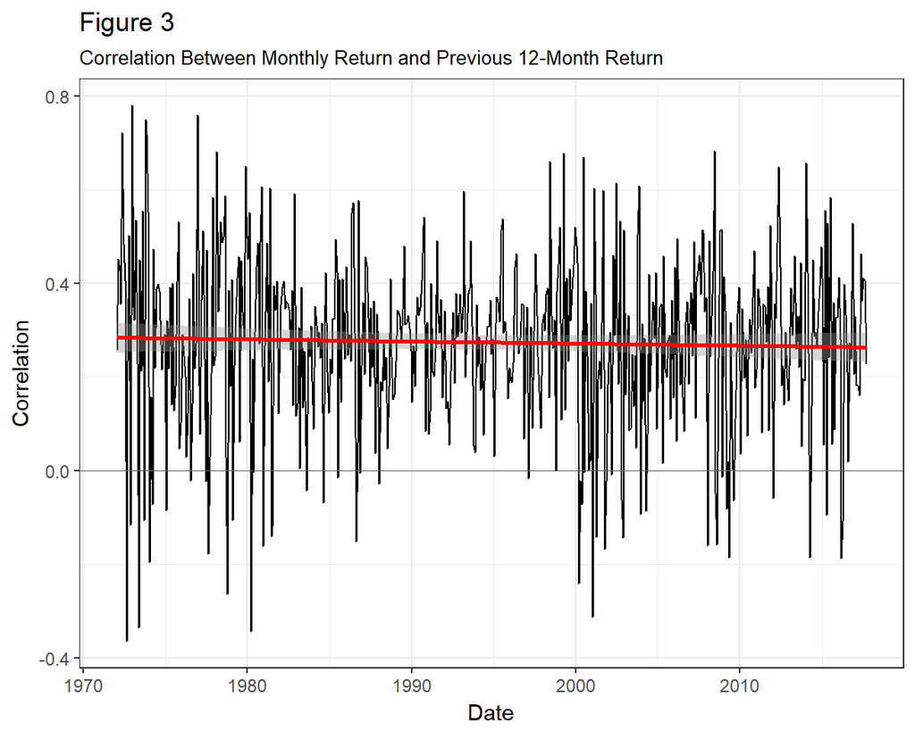

I run a simple linear regression of correlation on date over the sample time period in which 549 portfolios were constructed. The results appeared scattered and cannot be considered statistically significant. However, the slope coefficient of correlation over time is found to be -0.0008. This indicates that momentum has slightly declined over the time period examined, but has generally remained flat over the course of 45 years.

#### 5.3. Momentum Returns and the S&P 500

I compare the cumulative gains from the portfolios constructed by AMP and myself to the cumulative returns of the [Standard & Poor’s 500 (S&P 500)](http://www.multpl.com/s-p-500-historical-prices/table/by-month). The broad, market capitalization weighted index is an appropriate benchmark to compare the performance of an equity portfolio. Given that the momentum portfolios are zero cost, I construct a zero cost portfolio that is long the S&P 500 and short in a riskless asset that yields 0.5% per month. The performance of this investment strategy is compared to the cumulative returns of the portfolios constructed by AMP and myself in Figure 4.

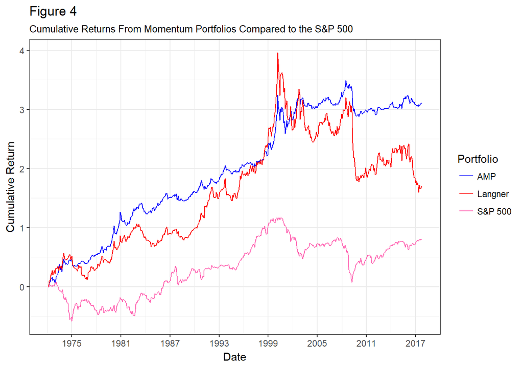

### 6. Alternative Momentum Strategies

The interpretation of momentum in financial markets and implementation in a portfolio can take many forms. This section describes additional modeling and alternative methods of portfolio construction based on momentum, separate from that of AMP.

#### 6.1. Strong Signals

The first alternative momentum strategy that I pursue is straightforward. Instead of including each of the top 500 stocks ranked by monthly trading value, I only include the top and bottom decile of securities with the strongest momentum signals. That is, of the 500 stocks available, I include those which were originally ranked 1-50 (the worst) and 451-500 (the best). By excluding the 400 stocks with weaker signals, the portfolio is only acting upon securities which exhibited very clear and robust gains or losses over the previous 12 months.

I begin this method of portfolio construction in 1990 to include a full 12 months of data for each of the 500 stocks present in the portfolio. Each stock receives a new rank based on the 100 stocks that would be present in each portfolio, as described in section 3. Each stock is then given a new weight and a portfolio is constructed each month based on the returns of the previous 12 months.

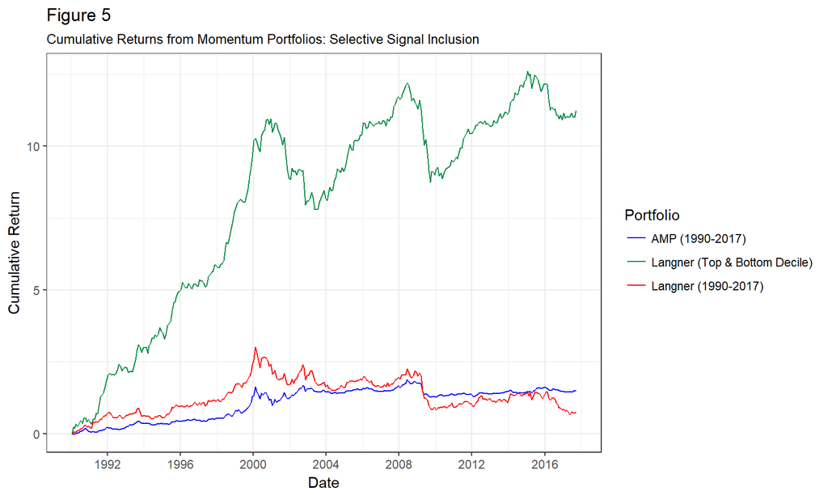

The cumulative returns observed with this method of portfolio construction since 1990 demonstrate a high level of profitability. Figure 5 displays the cumulative gains from this portfolio accumulated since 1990, compared to portfolios held over the same period which follow the original methodology and do not exclude stocks based on the strength of their momentum signals. Table III displays the descriptive statistics of the monthly stock data for the top and bottom decile of stocks. Table IV compares the results from the original portfolio modeled after AMP to the new model that includes only the top and bottom decile of stocks.

**Table III**

| Statistic | N | Mean | St. Dev. | Min | Median | Max |
| --- | --- | --- | --- | --- | --- | --- |
| 1-Month Return | 33,300 | 0.024 | 0.218 | -0.902 | 0.013 | 11.706 |
| 12-Month Return | 33,300 | 0.612 | 1.815 | -0.991 | 0.044 | 93.214 |
| Descriptive statistics of individual stock returns that demonstrate the strongest momentum signals from January 1990 through September 2017. |  |  |  |  |  |  |

It can be seen that the new data set which includes definitively volatile stocks is indeed more volatile than the original monthly data set that includes all 500 stocks for a portfolio. The upward bias previously discussed in section 4.3 appears to be even more present in this collection of data. This is expected, as the least and greatest return values remain present, without the presence of stocks that display less volatility to lower to mean return values.

**Table IV**

[output not shown]

The results reported in Table IV and displayed in Figure 5 indicate that a momentum portfolio consisting of the top and bottom deciles of stocks significantly outperforms a portfolio which does not exclude stocks that exhibit weaker signals of momentum. Volatility of the top and bottom decile portfolio also rises significantly. This is intuitive to the notion that portfolios constructed with this method only include the most volatile stocks present in the data.

This thesis does not directly address the topic of transaction costs, however it is important to note that the method of portfolio construction described in this section would logically incur lower transaction costs as it only involves trading 100 securities at each point of portfolio construction, opposed to 500.

I find correlation between 1-month return and 12-month return within this method of portfolio construction which exceeds the correlation found when implementing AMP’s method of portfolio construction. Mean correlation between 1-month return and 12-month return from 1990 through 2017 across all 500 individual stocks is calculated to be 0.271. Mean correlation across the same timeline while only examining the 100 stocks with the strongest signals is calculated to be 0.358. A graph comparing correlations across both strategies is displayed in Figure 6. The correlation across the portfolios I construct from 1990 to 2017 with the original methodology is displayed in black. The correlation following the method of portfolio construction based on the 100 strongest signals is displayed in green.

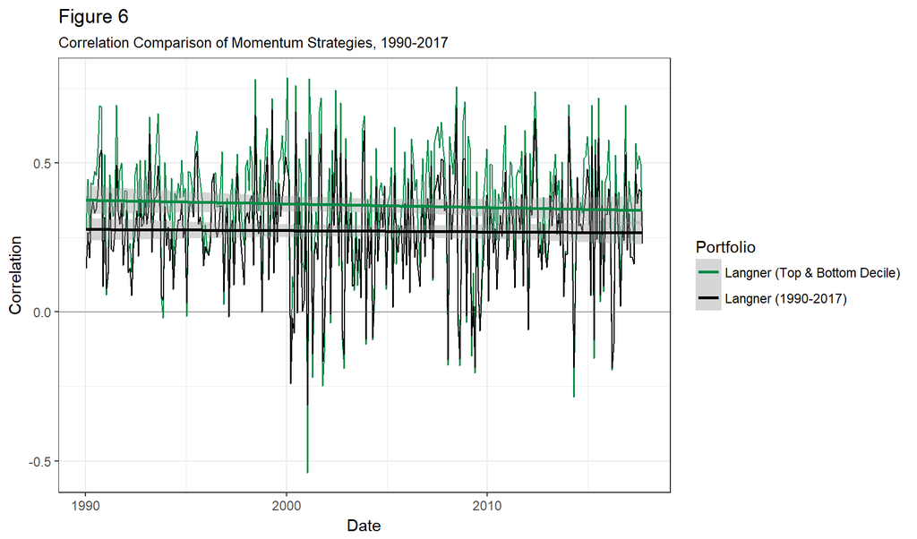

#### 6.2. Alternative Timeline of Momentum

The second alternative momentum strategy that I examine calculates the momentum signal based on past 6-month return, instead of 12-month return. I evaluate the performance of momentum portfolio construction from 6-month signals over the same timeline as the original portfolio modeled after AMP. This was done to compare an alternative timeline for examining momentum signals compared to the original portfolio. A visual of the results is presented in Figure 7.

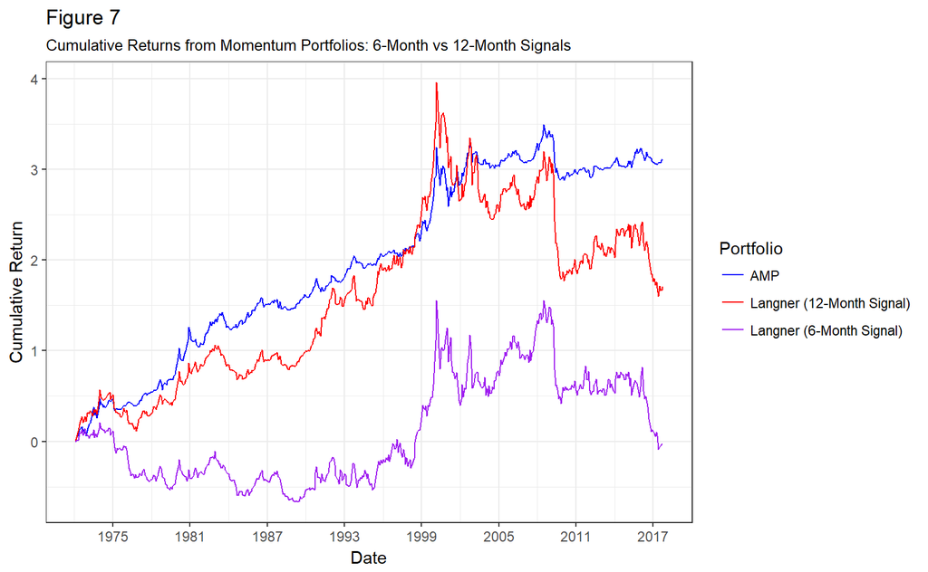

It is evident that a portfolio constructed from 6-month momentum signals underperforms portfolios constructed from 12-month signals. The performance of the portfolio exhibited in Figure 7 demonstrates negative cumulative returns from 1975 until approximately 1999, and proceeds to follow a similar pattern to the portfolios constructed from 12-month momentum signals during the period spanning from 1999 to 2017.

**Table V**

| Statistic | N | Mean | St. Dev. | Min | Median | Max |
| --- | --- | --- | --- | --- | --- | --- |
| 1-Month Return | 204,082 | 0.017 | 0.134 | -0.902 | 0.012 | 11.706 |
| 6-Month Return | 204,082 | 0.117 | 0.440 | -0.971 | 0.074 | 45.833 |
| Descriptive statistics of individual stock returns over the course of 1 month and 6 months. |  |  |  |  |  |  |

Table VI compares the performance of the original portfolio constructed in section 5 to the new portfolio that uses momentum signals of 6 months.

**Table VI**

| Statistic | N | Mean | St. Dev. | Min | Median | Max |
| --- | --- | --- | --- | --- | --- | --- |
| 12-Month Signals | 549 | 0.003 | 0.081 | -0.521 | 0.008 | 0.440 |
| 6-Month Signals | 549 | -0.0001 | 0.079 | -0.476 | 0.002 | 0.441 |
| Descriptive statistics of the returns from portfolios constructed with 12-month momentum signals and portfolios constructed with 6-month momentum signals. |  |  |  |  |  |  |

Based on the negative cumulative returns observed in Figure 7, I expected to find that the correlation between 1-month return and 12-month return would be higher than the correlation between 1-month return and 6-month return, however Figure 8 shows that this is not the case. The mean correlation between 1-month return and 6-month return across the 549 portfolios constructed is 0.394, which far exceeds the mean correlation between 1-month return and 12-month return over the same sample time period, which is 0.274. While average correlation for the 6-month momentum portfolio is high, it is possible that the performance of the portfolio is driven by a few outliers. The timeline of the portfolio’s poor performance is concurrent with the time period in which there are fewer stocks included in the portfolio. When the portfolio experienced significant cumulative losses in 1975, there were only 73 stocks used to construct the portfolio, which would allow outliers to have more of an affect on the overall performance of the portfolio.

[Jegadeesh and Titman (2001)](https://www.jstor.org/stable/222579?seq=1#page_scan_tab_contents) evaluate momentum signals with 6 months of returns, however the portfolios are held for 6 months opposed to just 1 month. It is not entirely clear if my data and methods of portfolio construction would allow for greater cumulative gains if the holding period for this type of momentum portfolio was extended to 6 months.

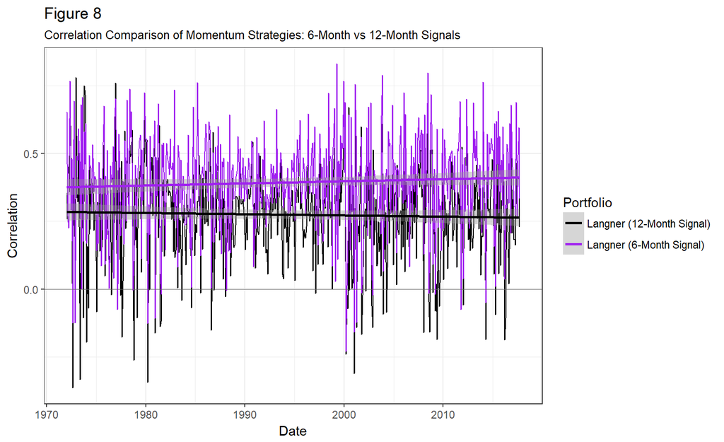

### 7. Conclusion

I successfully replicated the findings of AMP with different, lower quality data and a different sample of stocks and found consistent evidence of momentum in the United States equity markets from 1972 through 2017. I find that cumulative returns to momentum portfolios constructed from the top and bottom decile of performers are noticeably greater than portfolios constructed from the top and bottom half of performers. Additionally, I find that portfolios constructed from 6-month momentum signals are significantly less profitable that the portfolios constructed from 12 month momentum signals. Finally, I find that cumulative returns to momentum portfolios outperform zero cost portfolios that are long the S&P 500 and short in a riskless asset that yields 0.5% per month.

An important caveat is that the momentum portfolios constructed in this thesis do not account for transaction costs. The United States equity markets are large and generally liquid, however there are still costs incorporated in the construction of such an active investment strategy. [Korajczyk and Sadka (2004)](http://onlinelibrary.wiley.com/doi/10.1111/j.1540-6261.2004.00656.x/abstract) construct long-only momentum portfolios on the basis of asymmetry in the transaction costs and liquidity between long and short positions in a zero cost portfolio. They find that the apparent profitability of equal weighted momentum strategies is lower than originally examined after accounting for the price impact of trading, however long-only portfolios remain quite profitable under the same conditions. Lesmond, Schill, and Zhou (2003) expand upon existing momentum literature by introducing trading costs into various portfolios, with the conclusion that the stocks which exhibit the strongest signals of momentum are generally smaller and less liquid, restricting momentum profitability to large, liquid stocks that tend to display weaker momentum signals. Frazzini, Israel, and Moskowitz (2012) also find robust profits among momentum portfolios constructed with large market capitalization equities when examining the actual transaction costs obtained from one trillion dollars of live trading data. This literature implies that the strategies implemented in this thesis would remain profitable when accounting for transaction costs due to the nature of the large, liquid securities used to construct momentum portfolios.

The literature discussed above examines the costs of portfolio construction from the perspective of an institutional investor such as a mutual fund or hedge fund. I conducted this thesis without access to the tools and resources that are available to professional money managers, which also poses potential problems for implementation. Investing with a company such as a [Charles Schwab](https://www.schwab.com/public/schwab/investing/pricing_services/fees_minimums/) would cost approximately $5 per transaction for a long position, and [short positions](https://www.schwab.com/active-trader/insights/content/9-frequently-asked-questions-about-short-selling) would cost additional money as well as a required margin account for the positions. Charles Schwab requires an initial margin account of $5,000 to even begin the process of short selling. Furthermore, the strategies that I examine through the process of ranking and weighting stocks involves quantities that are not round numbers of shares. These complications suggest that the average retail investor would have difficulty constructing a full momentum portfolio and would likely benefit from examining momentum as a risk factor when evaluating securities to be held in a personal portfolio.

Evidence of momentum does not directly suggest that it is an appropriate portfolio construction strategy for every investor. [Carhart (1997)](http://onlinelibrary.wiley.com/doi/10.1111/j.1540-6261.1997.tb03808.x/full) extends the widely used Fama-French Three-Factor Model for asset pricing by incorporating momentum as a risk factor in a model that factors market risk, size, and value. This four-factor model accurately demonstrates that momentum portfolios contain greater risk and therefore provide an opportunity for excess returns to the market. [Cochrane (1999)](http://faculty.chicagobooth.edu/john.cochrane/research/papers/ep3q99_4.pdf) provides a comprehensive discussion of bearing investment risk in relation to existing assets, as well as risk exposure outside of one’s portfolio, such as employment. For example, the poor performance of momentum portfolios during market crashes suggests that it is not an appropriate investment strategy for an individual whose employment depends on the state of the equity markets. Alternatively, an investor with secure employment that is independent of the market is in a better position to accumulate risk that others actively avoid, providing the opportunity for abnormally high returns.

It is my hope that this research will serve two purposes in the future: First, to educate investors on the momentum anomaly and the opportunities to take on this risk by those who can bear it, and second, to act as a foundation from which future research on momentum can be conducted, including the transaction costs of this investment strategy, as well as alternative methods and timelines of the portfolios that I present in this thesis.

### References

Asness, Clifford S., Tobias J. Moskowitz, and Lasse Heje Pedersen. “Value and Momentum Everywhere.” The Journal of Finance 68, no. 3 (June 20, 2013): 929-85. doi:10.1111/jofi.12021.

Bollen, Nicolas P. B., and Jeffrey A. Busse. “Short-Term Persistence in Mutual Fund Performance.” Review of Financial Studies 18, no. 2 (August 25, 2004): 569-97. doi:10.1093/rfs/hhi007.

Carhart, M. M. (1997), On Persistence in Mutual Fund Performance. The Journal of Finance, 52: 57–82. doi:10.1111/j.1540-6261.1997.tb03808.x

Cochrane, John. “Portfolio Advice for a Multifactor World.” Economic Perspectives, Federal Reserve Bank of Chicago 23, no. 3 (June 1999): 59-78. doi:10.3386/w7170.

Fama, Eugene F., and Kenneth R. French. “Common risk factors in the returns on stocks and bonds.” Journal of Financial Economics 33, no. 1 (1993): 3-56. doi:10.1016/0304-405x(93)90023-5.

Frazzini, Andrea, Ronen Israel, and Tobias J. Moskowitz. “Trading Costs of Asset Pricing Anomalies.” Fama-Miller Center for Research in Finance 14, no. 05 (December 5, 2012).

Grann, Andreas. “Portfolio construction based on value and momentum: a winning strategy?” Master’s thesis, Lund University, 2017.

Gray, Wesley R., and Jack R. Vogel. Quantitative Momentum A Practitioner’s Guide to Building a Momentum-based Stock Selection System. Hoboken, NJ: Wiley, 2016.

Gutierrez, Roberto C., Michael J. Cooper, and Allaudeen Hameed. “Market States and Momentum.” The Journal of Finance 59, no. 3 (June 2004): 1345-365. doi:10.2139/ssrn.299927.

Jegadeesh, Narasimhan, and Sheridan Titman. “Profitability of Momentum Strategies: An Evaluation of Alternative Explanations.” The Journal of Finance 56, no. 2 (April 2001): 699-720. doi:10.3386/w7159.

Korajczyk, Robert A., and Ronnie Sadka. “Are Momentum Profits Robust to Trading Costs?” The Journal of Finance 59, no. 3 (June 2004): 1039-082. doi:10.2139/ssrn.305282.

Lesmond, David A., Michael J. Schill, and Chunsheng Zhou. “The Illusory Nature of Momentum Profits.” SSRN Electronic Journal, 2003. doi:10.2139/ssrn.256926.

Quandl.com. “Wiki EOD Stock Prices”. Accessed October 5, 2017.

Rachev, Svetlozar, Teo Jašić, Stoyan Stoyanov, and Frank J. Fabozzi. “Momentum Strategies Based on Reward–Risk Stock Selection Criteria.” Journal of Banking & Finance 31, no. 8 (February 2007): 2325-346.doi:10.1016/j.jbankfin.2007.02.006.

S&P 500 Historical Prices by Month. Accessed February 12, 2018. http://www.multpl.com/s-p-500-historical-prices/table/by-month.

Sec.gov. “Final Rule: Amendments to Investment Company Advertising Rules.” Rule 156 [17 CFR 230.156]. November 15, 2003.

Value and Momentum Everywhere: Portfolios, Monthly. XLS. Greenwich, CT: AQR Capital Management, January 31, 2018.

“We believe you should always know what you’re paying and never overpay.” Charles Schwab. https://www.schwab.com/public/schwab/investing/pricing_services/fees_minimums/.

“9 Frequently Asked Questions About Short Selling.” Schwab Brokerage. https://www.schwab.com/active-trader/insights/content/9-frequently-asked-questions-about-short-selling.